# HW3-EDA with R - Part 2: Group by analysis

misken

January 22, 2018

## Step 1 - Familiarize yourself with the data and the assignment

In this assignment you’ll do some exploratory data analysis with R on a dataset US census information based on the [American Community Survey](https://www.census.gov/programs-surveys/acs/). The version of this data that we’ll be using is from a Kaggle dataset. See https://www.kaggle.com/muonneutrino/us-census-demographic-data/data and look at the column metadata for the county level table to see what the various columns mean.

As we did in class, you’ll be creating an R Markdown document to both prepare a dataset and do some analysis as well as to document the steps you did (and answer some questions I’ll throw at you).

You’ll notice a few “Hacker Extra” tasks thrown in. These are for those of you who want to go a little above and beyond and attempt some more challenging tasks.

## Step 2 - Create a new R Markdown document

Save this file as a new R Markdown document and name it **HW3_EDA2wR_[*your last name*].Rmd**. Mine would be called **HW3_EDA2wR_isken.Rmd**. Save it into the same folder as this file.

This will be your working directory.

## Step 3 - Set working directory and explore data folder

Create an R Studio project in the current folder. You’ll notice that there is a folder named **data**. Inside of it you’ll find the data files for this assignment:

- **acs2015_census_tract_data.csv**
- **acs2015_county_data.csv**
- **us_census_bureau_regions_and_divisions.csv**
- **county_MI.csv**

The first two files are from the Kaggle site for this dataset. The last file, **county_MI.csv**, is a file that I created and just contains data from Michigan. The R script, **census_data_prep.R** was used to create the file as well as to merge information from the **us_census_bureau_regions_and_divisions.csv** file with the county data.

## Step 4 - Complete the following R tasks and answer questions

Now you’ll need to complete the following tasks in R. Just like we did in class, you should use a combination of markdown text (be concise, no need to write tons of text) to explain what you are doing and R code chunks to actually do it. When you are done, use the “Knit” button to generate an HTML file from your R Markdown. You’ll be submitting BOTH the completed R Markdown file as well as the generated HTML file. You’ll notice that I’ve left some empty code chunks as well as some partially filled in code chunks. Of course, feel free to add more code chunks as needed.

Let’s load a few libraries we’ll need:

```r
library(plyr)
library(dplyr)
```

```r
library(ggplot2)
library(tidyr)
library(psych)
```

Let’s read in the data.

```r
county_df <- read.csv(file='data/county.csv')
county_MI <- read.csv(file='data/county_MI.csv')
```

The county_MI data frame contains data for Michigan only and includes an peninsula field. See **census_data_prep.R** to see how this field was created. It involves scraping a table out of a web page.

### Problem 1 - Basic filtering

Use county_MI.

Using basic R commands (i.e. **no plyr or dplyr**) list all the rows for counties in the Upper Peninsula.

```r
subset(county_MI, county_MI$peninsula =="UP")
```

```
##         County peninsula    State CensusId State.Code  Region
## 2        Alger        UP Michigan    26003         MI Midwest
## 7       Baraga        UP Michigan    26013         MI Midwest
## 17    Chippewa        UP Michigan    26033         MI Midwest
## 21       Delta        UP Michigan    26041         MI Midwest
## 22   Dickinson        UP Michigan    26043         MI Midwest
## 27     Gogebic        UP Michigan    26053         MI Midwest
## 31    Houghton        UP Michigan    26061         MI Midwest
## 36        Iron        UP Michigan    26071         MI Midwest
## 42    Keweenaw        UP Michigan    26083         MI Midwest
## 48        Luce        UP Michigan    26095         MI Midwest
## 49    Mackinac        UP Michigan    26097         MI Midwest
## 52   Marquette        UP Michigan    26103         MI Midwest
## 55   Menominee        UP Michigan    26109         MI Midwest
## 66   Ontonagon        UP Michigan    26131         MI Midwest
```

[output cut: 97 more lines]

Now do the same thing but use dplyr. Do NOT use the pipe operator.

```r
filter(county_MI, county_MI$peninsula =="UP")
```

```
##         County peninsula    State CensusId State.Code  Region
## 1        Alger        UP Michigan    26003         MI Midwest
## 2       Baraga        UP Michigan    26013         MI Midwest
## 3     Chippewa        UP Michigan    26033         MI Midwest
## 4        Delta        UP Michigan    26041         MI Midwest
## 5    Dickinson        UP Michigan    26043         MI Midwest
## 6      Gogebic        UP Michigan    26053         MI Midwest
## 7     Houghton        UP Michigan    26061         MI Midwest
## 8         Iron        UP Michigan    26071         MI Midwest
## 9     Keweenaw        UP Michigan    26083         MI Midwest
## 10        Luce        UP Michigan    26095         MI Midwest
## 11    Mackinac        UP Michigan    26097         MI Midwest
## 12   Marquette        UP Michigan    26103         MI Midwest
## 13   Menominee        UP Michigan    26109         MI Midwest
## 14   Ontonagon        UP Michigan    26131         MI Midwest
```

[output cut: 97 more lines]

Repeat using dplyr and using the pipe operator.

```r
county_MI %>% filter(peninsula =="UP")
```

```
##         County peninsula    State CensusId State.Code  Region
## 1        Alger        UP Michigan    26003         MI Midwest
## 2       Baraga        UP Michigan    26013         MI Midwest
## 3     Chippewa        UP Michigan    26033         MI Midwest
## 4        Delta        UP Michigan    26041         MI Midwest
## 5    Dickinson        UP Michigan    26043         MI Midwest
## 6      Gogebic        UP Michigan    26053         MI Midwest
## 7     Houghton        UP Michigan    26061         MI Midwest
## 8         Iron        UP Michigan    26071         MI Midwest
## 9     Keweenaw        UP Michigan    26083         MI Midwest
## 10        Luce        UP Michigan    26095         MI Midwest
## 11    Mackinac        UP Michigan    26097         MI Midwest
## 12   Marquette        UP Michigan    26103         MI Midwest
## 13   Menominee        UP Michigan    26109         MI Midwest
## 14   Ontonagon        UP Michigan    26131         MI Midwest
```

[output cut: 97 more lines]

```r
county_MI %>% filter(TotalPop >= 200000)
```

```
##      County peninsula    State CensusId State.Code  Region
## 1   Genesee        LP Michigan    26049         MI Midwest
## 2    Ingham        LP Michigan    26065         MI Midwest
## 3 Kalamazoo        LP Michigan    26077         MI Midwest
## 4      Kent        LP Michigan    26081         MI Midwest
## 5    Macomb        LP Michigan    26099         MI Midwest
## 6   Oakland        LP Michigan    26125         MI Midwest
## 7    Ottawa        LP Michigan    26139         MI Midwest
## 8 Washtenaw        LP Michigan    26161         MI Midwest
## 9     Wayne        LP Michigan    26163         MI Midwest
##             Division TotalPop    Men  Women Hispanic White Black Native
## 1 East North Central   415874 200473 215401      3.2  72.5  20.3    0.4
## 2 East North Central   283491 137614 145877      7.5  71.3  10.8    0.3
## 3 East North Central   256752 125558 131194      4.5  78.7  10.6    0.2
## 4 East North Central   622590 305818 316772     10.0  75.1   9.3    0.3
```

[output cut: 45 more lines]

Counties with population greater than or equal to 200000 and sorted in descending order by population. Use dplyr.

```r
county_MI %>% filter(TotalPop >= 200000) %>% arrange(desc(TotalPop))
```

```
##      County peninsula    State CensusId State.Code  Region
## 1     Wayne        LP Michigan    26163         MI Midwest
## 2   Oakland        LP Michigan    26125         MI Midwest
## 3    Macomb        LP Michigan    26099         MI Midwest
## 4      Kent        LP Michigan    26081         MI Midwest
## 5   Genesee        LP Michigan    26049         MI Midwest
## 6 Washtenaw        LP Michigan    26161         MI Midwest
## 7    Ingham        LP Michigan    26065         MI Midwest
## 8    Ottawa        LP Michigan    26139         MI Midwest
## 9 Kalamazoo        LP Michigan    26077         MI Midwest
##             Division TotalPop    Men  Women Hispanic White Black Native
## 1 East North Central  1778969 855112 923857      5.5  49.8  39.2    0.3
## 2 East North Central  1229503 597097 632406      3.7  73.5  13.8    0.2
## 3 East North Central   854689 415691 438998      2.4  81.4  10.2    0.3
## 4 East North Central   622590 305818 316772     10.0  75.1   9.3    0.3
```

[output cut: 45 more lines]

Counties with median income between 30000 and 40000. Sort in ascending order by median income.

The arrange function automatically sorts by ascending order. piped the data frame to the subset function which was in turn piped to the arrange function

```r
county_MI %>% subset(Income>=30000 & Income<=40000) %>% arrange(Income)
```

```
##         County peninsula    State CensusId State.Code  Region
## 1         Lake        LP Michigan    26085         MI Midwest
## 2        Clare        LP Michigan    26035         MI Midwest
## 3       Oscoda        LP Michigan    26135         MI Midwest
## 4         Iron        UP Michigan    26071         MI Midwest
## 5  Schoolcraft        UP Michigan    26153         MI Midwest
## 6    Ontonagon        UP Michigan    26131         MI Midwest
## 7    Roscommon        LP Michigan    26143         MI Midwest
## 8      Gogebic        UP Michigan    26053         MI Midwest
## 9       Ogemaw        LP Michigan    26129         MI Midwest
## 10 Montmorency        LP Michigan    26119         MI Midwest
## 11        Luce        UP Michigan    26095         MI Midwest
## 12       Iosco        LP Michigan    26069         MI Midwest
## 13    Houghton        UP Michigan    26061         MI Midwest
## 14    Keweenaw        UP Michigan    26083         MI Midwest
```

[output cut: 153 more lines]

### Problem 2 - Selecting columns

Use county_MI.

Population by county sorted descending by population. Just show county and population.

```r
county_MI %>% arrange(desc(TotalPop)) %>% select(County, TotalPop)
```

```
##            County TotalPop
## 1           Wayne  1778969
## 2         Oakland  1229503
## 3          Macomb   854689
## 4            Kent   622590
## 5         Genesee   415874
## 6       Washtenaw   354092
## 7          Ingham   283491
## 8          Ottawa   273136
## 9       Kalamazoo   256752
## 10        Saginaw   196479
## 11     Livingston   184591
## 12       Muskegon   171483
## 13      St. Clair   160429
## 14        Jackson   159759
```

[output cut: 69 more lines]

Counties with population < 50000 and just the columns County, peninsula and TotalPop. Sort ascending by population.

```r
county_MI %>% filter(TotalPop <50000) %>% select(County, peninsula, TotalPop) %>% arrange(desc(TotalPop))
```

```
##          County peninsula TotalPop
## 1       Newaygo        LP    48029
## 2     Hillsdale        LP    46178
## 3        Branch        LP    43706
## 4       Mecosta        LP    43301
## 5       Sanilac        LP    42014
## 6       Gratiot        LP    41878
## 7      Chippewa        UP    38586
## 8         Delta        UP    36712
## 9      Houghton        UP    36660
## 10        Emmet        LP    33018
## 11      Wexford        LP    32751
## 12        Huron        LP    32290
## 13        Clare        LP    30710
## 14       Alpena        LP    29068
```

[output cut: 34 more lines]

Counties with population < 50000 and just the the first 5 columns (except for column 3) along with Income and Poverty. Sort descending by Poverty.

```r
county_MI %>% filter(TotalPop < 50000) %>% select(County, peninsula, CensusId, State.Code, Income, Poverty) %>% arrange(desc(Poverty))
```

```
##          County peninsula CensusId State.Code Income Poverty
## 1          Lake        LP    26085         MI  30439    28.7
## 2         Clare        LP    26035         MI  33015    26.1
## 3       Mecosta        LP    26107         MI  41889    23.1
## 4       Osceola        LP    26133         MI  38999    22.0
## 5        Ogemaw        LP    26129         MI  36063    21.8
## 6      Houghton        UP    26061         MI  37776    21.4
## 7   Schoolcraft        UP    26153         MI  34118    21.4
## 8       Gladwin        LP    26051         MI  38021    20.7
## 9     Roscommon        LP    26143         MI  35133    20.6
## 10       Oceana        LP    26127         MI  41617    20.4
## 11      Gogebic        UP    26053         MI  35686    20.2
## 12    Hillsdale        LP    26059         MI  41961    20.1
## 13       Arenac        LP    26011         MI  38307    19.9
## 14       Oscoda        LP    26135         MI  33021    19.8
```

[output cut: 34 more lines]

Counties with population > 100000 and just the the first 2 columns, TotalPop, and any column starting with “Inc”. Sort descending by Income.

```r
county_MI %>% filter(TotalPop > 100000) %>% select(County, peninsula, TotalPop, Income, IncomeErr, IncomePerCap, IncomePerCapErr) %>% arrange(desc(Income))
```

```
##        County peninsula TotalPop Income IncomeErr IncomePerCap
## 1  Livingston        LP   184591  75204       906        33619
## 2     Oakland        LP  1229503  67465       680        37728
## 3   Washtenaw        LP   354092  61003       901        34738
## 4      Ottawa        LP   273136  58989      1424        26519
## 5      Monroe        LP   150436  55653      1535        26982
## 6       Eaton        LP   108341  54993      1364        27577
## 7      Macomb        LP   854689  54582       606        27525
## 8     Allegan        LP   112837  54264      1359        25161
## 9        Kent        LP   622590  53063       550        27032
## 10  St. Clair        LP   160429  49730      1147        25429
## 11  Kalamazoo        LP   256752  47476       980        26416
## 12    Jackson        LP   159759  46326      1459        23377
## 13     Ingham        LP   283491  45679       852        25436
## 14        Bay        LP   106698  45583      1434        24445
```

[output cut: 27 more lines]

### Problem 3 - Create new columns with mutate

Use county_MI.

Create a new column called pct_F which is the percentage of females in that county. First do it by NOT saving the computed column. Just compute it and display the columns County, TotalPop, pct_F. Sort descending by pct_F.

```r
 county_MI %>%
   mutate(pct_F = Women/TotalPop) %>%
   select(County, TotalPop, pct_F) %>%
   arrange(desc(pct_F))
```

```
##            County TotalPop     pct_F
## 1           Wayne  1778969 0.5193216
## 2         Genesee   415874 0.5179477
## 3         Saginaw   196479 0.5153884
## 4        Isabella    70669 0.5150490
## 5          Ingham   283491 0.5145737
## 6         Oakland  1229503 0.5143591
## 7          Macomb   854689 0.5136348
## 8           Eaton   108341 0.5122622
## 9         Calhoun   134790 0.5114994
## 10        Berrien   155565 0.5112911
## 11      Kalamazoo   256752 0.5109756
## 12         Alpena    29068 0.5088757
## 13           Kent   622590 0.5087971
## 14        Midland    83624 0.5083349
```

[output cut: 69 more lines]

Now compute pct_F and save the pct_F column (along with the existing columns) in a new data frame called county_MI_x.

```r
county_MI_x <- county_MI %>%
   mutate(pct_F = Women/TotalPop) %>%
   select(County, TotalPop, pct_F)
```

Show that it worked by using select to show County, TotalPop, pct_F in the new data frame.

```r
 county_MI_x %>%
   select(County, TotalPop, pct_F)
```

```
##            County TotalPop     pct_F
## 1          Alcona    10550 0.4966825
## 2           Alger     9476 0.4493457
## 3         Allegan   112837 0.5018921
## 4          Alpena    29068 0.5088757
## 5          Antrim    23267 0.5019985
## 6          Arenac    15424 0.4934518
## 7          Baraga     8690 0.3941312
## 8           Barry    59147 0.4973033
## 9             Bay   106698 0.5078352
## 10         Benzie    17437 0.5006022
## 11        Berrien   155565 0.5112911
## 12         Branch    43706 0.4843042
## 13        Calhoun   134790 0.5114994
## 14           Cass    51952 0.4964775
```

[output cut: 69 more lines]

County with highest percentage of women? Lowest percentage of women? Create dplyr statements that make it easy to answer these questions.

```r
 county_MI_x %>%
   select(County, TotalPop, pct_F) %>% arrange(desc(pct_F))
```

```
##            County TotalPop     pct_F
## 1           Wayne  1778969 0.5193216
## 2         Genesee   415874 0.5179477
## 3         Saginaw   196479 0.5153884
## 4        Isabella    70669 0.5150490
## 5          Ingham   283491 0.5145737
## 6         Oakland  1229503 0.5143591
## 7          Macomb   854689 0.5136348
## 8           Eaton   108341 0.5122622
## 9         Calhoun   134790 0.5114994
## 10        Berrien   155565 0.5112911
## 11      Kalamazoo   256752 0.5109756
## 12         Alpena    29068 0.5088757
## 13           Kent   622590 0.5087971
## 14        Midland    83624 0.5083349
```

[output cut: 69 more lines]

```r
county_MI_x %>%
   select(County, TotalPop, pct_F) %>% arrange(pct_F)
```

```
##            County TotalPop     pct_F
## 1          Baraga     8690 0.3941312
## 2            Luce     6477 0.4151613
## 3           Alger     9476 0.4493457
## 4        Chippewa    38586 0.4517182
## 5        Houghton    36660 0.4578287
## 6         Gogebic    15824 0.4593023
## 7         Gratiot    41878 0.4695783
## 8           Ionia    64064 0.4705763
## 9        Keweenaw     2198 0.4790719
## 10       Manistee    24536 0.4818226
## 11         Branch    43706 0.4843042
## 12       Montcalm    63004 0.4844454
## 13         Oscoda     8444 0.4853150
## 14      Ontonagon     6298 0.4857097
```

[output cut: 69 more lines]

Now create the following histogram using the ideas from the previous queries.

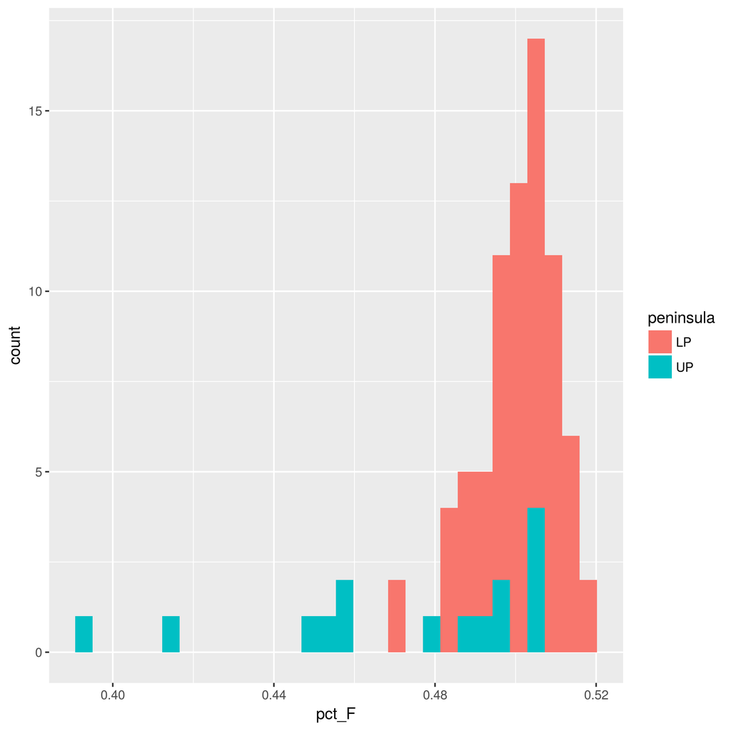

```r
knitr::include_graphics('images/histos_pctF_by_peninsula.png')
```

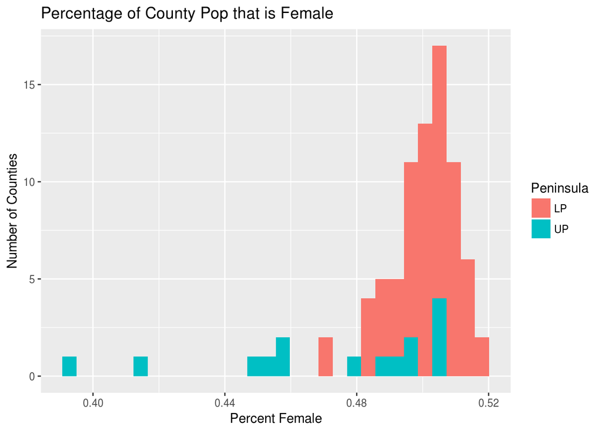

```r
county_MI_xx <- county_MI %>%
   mutate(pct_F = Women/TotalPop) %>%
   select(County, TotalPop, pct_F, peninsula)

ggplot(county_MI_xx) + geom_histogram(aes(x=county_MI_xx$pct_F, fill =county_MI_xx$peninsula)) + ggtitle("Percentage of County Pop that is Female") + xlab("Percent Female") + ylab("Number of Counties") + labs(fill="Peninsula")
```

Confirm that the columns Professional, Service, Office, Construction, and Production sum up to 100 (within +- .105). There are a number of ways to do this. You could use `mutate` and/or use base R commands.

you can tell from the summary that the error is not violated from the min and max values, just to be sure one can always compare the values giving true or false output.

```r
 tot_job_type <- county_MI$Professional + county_MI$Service + county_MI$Office + county_MI$Construction + county_MI$Production
summary(tot_job_type)
```

```
##    Min. 1st Qu.  Median    Mean 3rd Qu.    Max.
##    99.9   100.0   100.0   100.0   100.0   100.1
```

```r
err_tol <- 0.105
lowerbound <- 100-err_tol
upperbound <- 100+err_tol
tot_job_type >= lowerbound
```

```
##  [1] TRUE TRUE TRUE TRUE TRUE TRUE TRUE TRUE TRUE TRUE TRUE TRUE TRUE TRUE
## [15] TRUE TRUE TRUE TRUE TRUE TRUE TRUE TRUE TRUE TRUE TRUE TRUE TRUE TRUE
## [29] TRUE TRUE TRUE TRUE TRUE TRUE TRUE TRUE TRUE TRUE TRUE TRUE TRUE TRUE
## [43] TRUE TRUE TRUE TRUE TRUE TRUE TRUE TRUE TRUE TRUE TRUE TRUE TRUE TRUE
## [57] TRUE TRUE TRUE TRUE TRUE TRUE TRUE TRUE TRUE TRUE TRUE TRUE TRUE TRUE
## [71] TRUE TRUE TRUE TRUE TRUE TRUE TRUE TRUE TRUE TRUE TRUE TRUE TRUE
```

```r
tot_job_type <= upperbound
```

```
##  [1] TRUE TRUE TRUE TRUE TRUE TRUE TRUE TRUE TRUE TRUE TRUE TRUE TRUE TRUE
## [15] TRUE TRUE TRUE TRUE TRUE TRUE TRUE TRUE TRUE TRUE TRUE TRUE TRUE TRUE
## [29] TRUE TRUE TRUE TRUE TRUE TRUE TRUE TRUE TRUE TRUE TRUE TRUE TRUE TRUE
## [43] TRUE TRUE TRUE TRUE TRUE TRUE TRUE TRUE TRUE TRUE TRUE TRUE TRUE TRUE
## [57] TRUE TRUE TRUE TRUE TRUE TRUE TRUE TRUE TRUE TRUE TRUE TRUE TRUE TRUE
## [71] TRUE TRUE TRUE TRUE TRUE TRUE TRUE TRUE TRUE TRUE TRUE TRUE TRUE
```

### Summarization

Use county_MI.

Find total population by peninsula using dplyr.

```r
county_MI %>%
   group_by(peninsula) %>%
   summarise(sum(TotalPop))
```

```
## # A tibble: 2 x 2
##   peninsula `sum(TotalPop)`
##   <fct>               <int>
## 1 LP                9591500
## 2 UP                 309071
```

Number of counties by peninsula.

By counting the number of times that peninsula occurs, you get the number of counties in each respective peninsula.

```r
# One way to do it is with the "shortcut" function count().
county_MI %>%
   count(peninsula)
```

```
## # A tibble: 2 x 2
##   peninsula     n
##   <fct>     <int>
## 1 LP           68
## 2 UP           15
```

Repeat the two previous queries using plyr instead of dplyr.

```r
ddply(county_MI, .(peninsula), summarise, TotalPop = sum(TotalPop))
```

```
##   peninsula TotalPop
## 1        LP  9591500
## 2        UP   309071
```

```r
ddply(.data = county_MI, .variables = .(county_MI$peninsula), .fun = count)
```

```
##   county_MI$peninsula  n
## 1                  LP 68
## 2                  UP 15
```

Compute the following statistics for median Income by peninsula.

Let’s be perfectly clear, we are computing statistics based on medians which is not the same as computing the statistics by the grouping variables. We don’t have the raw data. So, we just need to be clear that these are summary stats of a median income.

- mean, median, 5% trimmed mean
- range, standard deviation, coefficient of variation, IQR
- 5th, 25th, 50th, 75th and 95th quantiles

```r
county_MI %>%
  group_by(peninsula) %>%
  do(describe(.$Income)) %>%
  select(-vars)
```

```
## # A tibble: 2 x 13
## # Groups:   peninsula [2]
##   peninsula     n  mean    sd median trimmed   mad   min   max range  skew
##   <fct>     <dbl> <dbl> <dbl>  <dbl>   <dbl> <dbl> <dbl> <dbl> <dbl> <dbl>
## 1 LP         68.0 45719  8108  43730   45093  5973 30439 75204 44765 1.04
## 2 UP         15.0 38782  3533  38434   38666  4074 33663 45409 11746 0.205
## # ... with 2 more variables: kurtosis <dbl>, se <dbl>
```

```r
#https://stackoverflow.com/questions/22240816/dplyr-summarise-with-multiple-return-values-from-a-single-function
# Artem Klevstov provides three good examples on summary statistics with different packages including purrr, data.table, # and dplyr

CV <- function(mean, sd){
      (sd/mean)*100
}

#https://alstatr.blogspot.com/2013/06/measure-of-relative-variability.html Abubakar Asaad provides instructions to make the cv function

 county_MI %>%
group_by(peninsula)    %>%
   summarize(CV(mean = mean(Income), sd = sd(Income)),
             IQR(Income))
```

```
## # A tibble: 2 x 3
##   peninsula `CV(mean = mean(Income), sd = sd(Income))` `IQR(Income)`
##   <fct>                                          <dbl>         <dbl>
## 1 LP                                             17.7           8093
## 2 UP                                              9.11          4796
```

```r
 county_MI %>%
group_by(peninsula)    %>%
   summarize(quantile(Income, probs = (0.05)),
             quantile(Income, probs = (0.25)),
             quantile(Income, probs = (0.5)),
             quantile(Income, probs = (0.75)),
             quantile(Income, probs = (0.95)))
```

```
## # A tibble: 2 x 6
##   peninsula `quantile(Income, pr… `quantile(Income, p… `quantile(Income, …
##   <fct>                     <dbl>                <dbl>               <dbl>
## 1 LP                        35458                41182               43730
## 2 UP                        33982                36387               38434
## # ... with 2 more variables: `quantile(Income, probs = (0.75))` <dbl>,
## #   `quantile(Income, probs = (0.95))` <dbl>
```

```r
 # The quantile function threw some errors when I tried to run it with seq it only gave me one column for all of the quantiles.
```

Now look at the entire US. What are the 5th, 50th, and 95th percentile of median income by state? Sort in descending ordery by median of median income.

```r
county_df %>%
  group_by(State) %>%
    summarize("5th percentile" = quantile(Income, probs = .05, na.rm = TRUE),
            "50th Percentile" = quantile(Income, probs = .5, na.rm = TRUE),
            "95th Percentile" = quantile(Income, probs = .95, na.rm = TRUE),
              medianincome = median(Income)) %>% arrange(desc(medianincome))
```

```
## # A tibble: 51 x 5
##    State   `5th percentile` `50th Percentil… `95th Percentil… medianincome
##    <fct>              <dbl>            <dbl>            <dbl>        <dbl>
##  1 Distri…            70848            70848            70848        70848
##  2 New Je…            53976            70471           100667        70471
##  3 Rhode …            52671            69526            72737        69526
##  4 Connec…            60179            69228            82714        69228
##  5 Maryla…            40804            66746            98894        66746
##  6 Hawaii             54707            66250            72863        66250
##  7 Alaska             42504            64222            83201        64222
##  8 Massac…            50284            63736            86218        63736
##  9 New Ha…            47259            59246            76719        59246
## 10 Wyoming            40627            56569            79586        56569
## # ... with 41 more rows
```

Which states have the highest average percentage of production workers? Just return the top 10 states and their Production values.

```r
State_Production <- county_df %>%
  group_by(State) %>%
  summarize(percent_production = mean(Production)) %>%
  arrange(desc(percent_production))

head(State_Production, 10)
```

```
## # A tibble: 10 x 2
##    State          percent_production
##    <fct>                       <dbl>
##  1 Indiana                      22.8
##  2 Alabama                      20.8
##  3 Ohio                         20.4
##  4 Tennessee                    20.2
##  5 Kentucky                     19.8
##  6 Mississippi                  19.3
##  7 Arkansas                     19.2
##  8 Wisconsin                    19.1
##  9 Iowa                         19.1
## 10 South Carolina               18.9
```

Which states have the lowest average percentage of people who drive to work? Be careful about those NA values…

```r
county_df %>%
  group_by(State) %>%
  summarize(Percent_Who_Drive = mean(Drive)) %>%
  arrange(Percent_Who_Drive)
```

```
## # A tibble: 51 x 2
##    State                Percent_Who_Drive
##    <fct>                            <dbl>
##  1 District of Columbia              33.7
##  2 Alaska                            46.8
##  3 Hawaii                            64.4
##  4 Montana                           69.6
##  5 Colorado                          70.6
##  6 South Dakota                      71.9
##  7 Nevada                            72.9
##  8 California                        73.2
##  9 North Dakota                      73.2
## 10 Oregon                            73.8
## # ... with 41 more rows
```

```r
county_df %>% filter(TotalPop > 75000) %>% group_by(State, County) %>%
  summarize(Percent_Who_Drive = mean(Drive)) %>% arrange(Percent_Who_Drive)
```

```
## # A tibble: 732 x 3
## # Groups:   State [51]
##    State                County               Percent_Who_Drive
##    <fct>                <fct>                            <dbl>
##  1 New York             New York                          6.10
##  2 New York             Kings                            18.6
##  3 New York             Bronx                            22.5
##  4 New York             Queens                           31.6
##  5 District of Columbia District of Columbia             33.7
##  6 California           San Francisco                    35.9
##  7 New Jersey           Hudson                           38.4
##  8 Massachusetts        Suffolk                          40.8
##  9 Pennsylvania         Philadelphia                     50.4
## 10 Virginia             Arlington                        54.2
## # ... with 722 more rows
```

Repeat the previous query for the state of Michigan.

```r
county_MI %>% filter(TotalPop > 75000) %>% group_by(State, County) %>%
  summarize(Percent_Who_Drive = mean(Drive)) %>% arrange(Percent_Who_Drive)
```

```
## # A tibble: 26 x 3
## # Groups:   State [1]
##    State    County         Percent_Who_Drive
##    <fct>    <fct>                      <dbl>
##  1 Michigan Washtenaw                   72.6
##  2 Michigan Ingham                      76.4
##  3 Michigan Calhoun                     80.8
##  4 Michigan Wayne                       81.0
##  5 Michigan Grand Traverse              81.4
##  6 Michigan Kent                        81.6
##  7 Michigan Jackson                     82.3
##  8 Michigan Berrien                     82.6
##  9 Michigan St. Clair                   82.6
## 10 Michigan Kalamazoo                   82.7
## # ... with 16 more rows
```

For this next question you do **not** need plyr or dplyr.

Create a correlation matrix for total population, per capita income and child poverty.

```r
Popdata <- data.frame(county_df$TotalPop, county_df$IncomePerCap, county_df$ChildPoverty)
cor(Popdata, y = NULL, use = "na.or.complete")
```

```
##                        county_df.TotalPop county_df.IncomePerCap
## county_df.TotalPop             1.00000000              0.2465392
## county_df.IncomePerCap         0.24653921              1.0000000
## county_df.ChildPoverty        -0.05014052             -0.6869267
##                        county_df.ChildPoverty
## county_df.TotalPop                -0.05014052
## county_df.IncomePerCap            -0.68692671
## county_df.ChildPoverty             1.00000000
```

Write a few sentences interpreting the correlation matrix.

Child poverty has a strong negative relationship with income per capita which is as it should be. Likewise, Income per capita has a strong negative impact on child poverty. Total population seems to have a weak positive relationship with income per capita and an alomost nonexistant relationship with child poverty.

**Hacker Extra**: Write a function that writes out the summary statistics like I did in this example from our Moodle site:

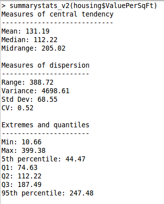

```r
knitr::include_graphics('images/SummaryStats_Output.png')
```

Compute the proportion of counties in the US with total population greater than 75000. You can do this very easily without dplyr. Hint: mean(). No need for plyr or dplyr.

```r
x <- sum(county_df$TotalPop >75000)
y <- sum(county_df$TotalPop < 75000)
x/y
```

```
## [1] 0.3037344
```

Use dplyr and ggplot along with the pipe operator to create a histogram of SelfEmployed for all counties in the US with total population > 75000.

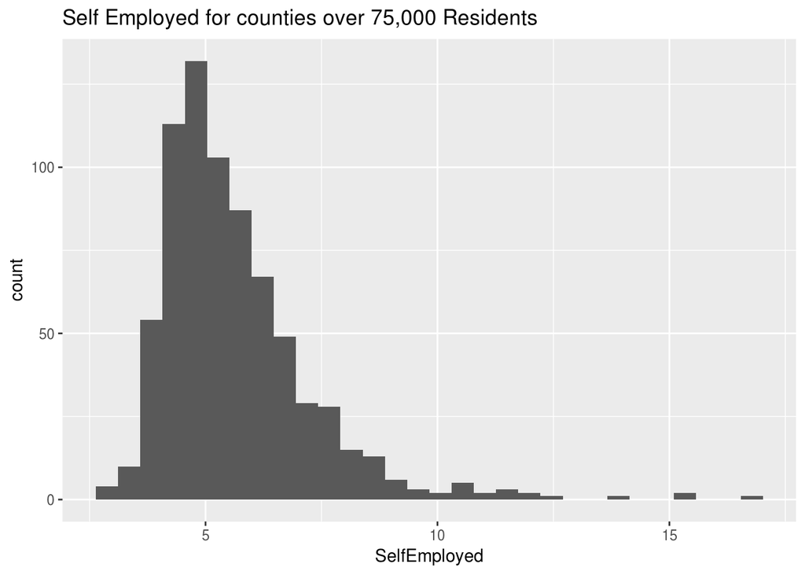

```r
 county_df %>%
   filter(TotalPop > 75000) %>% ggplot(mapping = aes(SelfEmployed)) + geom_histogram() + ggtitle("Self Employed for counties over 75,000 Residents")
```

Create a bar chart showing total population by region. Use dplyr as needed to create a data frame to plot. Hint: You’ll also want to learn about the `stat` layer in ggplot.

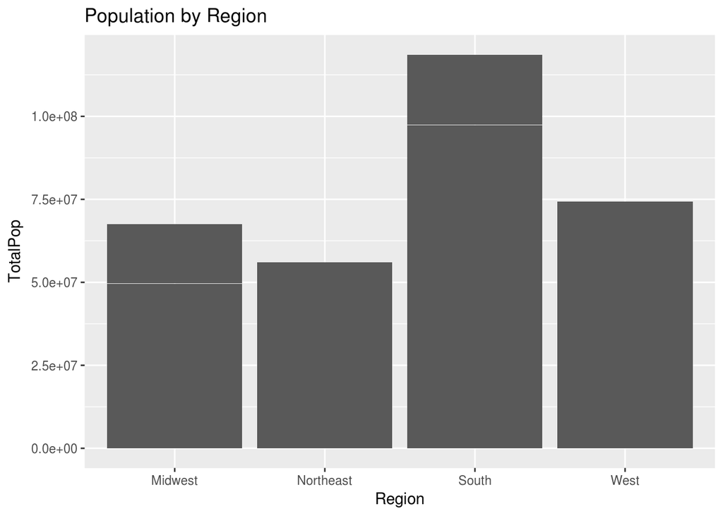

```r
pop_by_region <- county_df %>%
ggplot(aes(x =  Region, y = TotalPop)) + geom_bar(stat = "identity") + ggtitle("Population by Region")
pop_by_region
```

Now redo the previous plot but make it a horizontal bar plot and order the bars from longest to shortest.

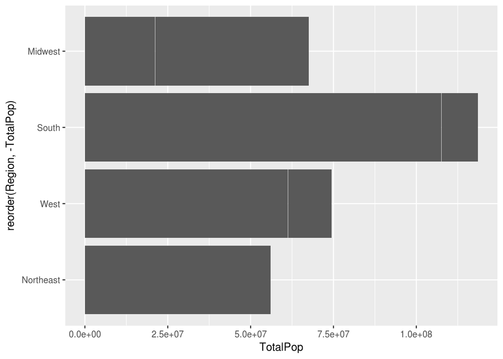

```r
county_df %>%
ggplot(aes(x = reorder(Region, -TotalPop), y = TotalPop)) + geom_bar(stat = "identity") + coord_flip()
```

```r
# I don't know why it does not work it reorders everything but Midwest, Midwest is always placed in the position that the largest bar should go. I would appreciate an explanation if you can figure out why this is happening
```

** Hacker Extra**

How do the three counties in the Metro Detroit area (Macomb, Oakland, Wayne) compare in terms of the breakdown of what kinds of jobs people have. Create a stacked bar chart. Mine looks like this:

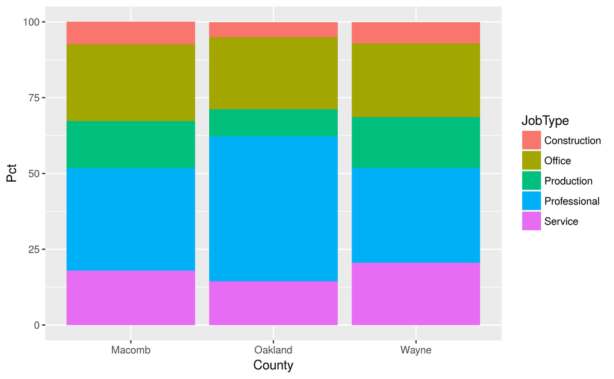

```r
knitr::include_graphics('images/stacked_bars.png')
```

Hint: The tidyr package is helpful.

```r
County_MI2 <- gather(county_MI, jobtypes, Pct, Professional:Production)
```

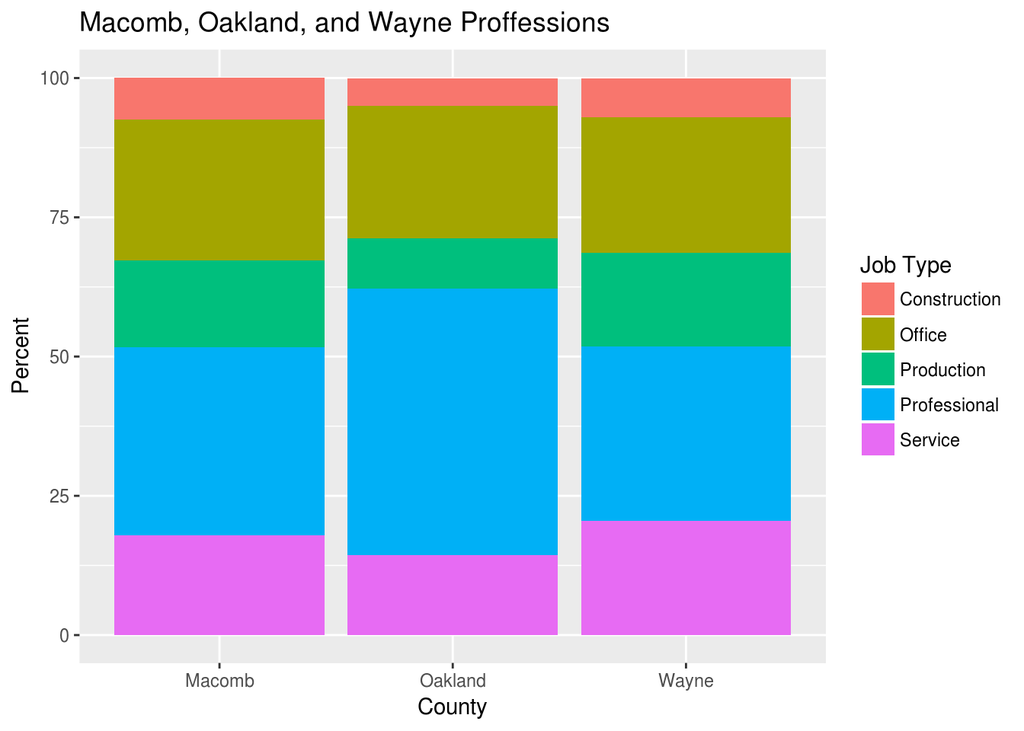

```r
MiCounties <- County_MI2 %>% filter(County %in% c('Macomb', 'Oakland', 'Wayne'))
ggplot(MiCounties) + geom_bar(aes(x=MiCounties$County, y = Pct, fill=MiCounties$jobtypes), stat="identity") + ylab("Percent") + xlab("County") + ggtitle("Macomb, Oakland, and Wayne Proffessions") + labs(fill="Job Type")
```

```r
# Here's how to save a plot to a file
ggsave('images/stacked_bars_test.png')
```

### Hacker Extra - Do some more analysis

Try a few things on your own to learn more about the counties in Michigan.